# Simulation

Tsz Keung Wong

Jorge Tendeiro

2026-03-10

This folder contains the R scripts for running simulations used to verify our method.

## General Procedure of the Simulation

The simulation process consists of three steps:

1. **Generating effect sizes**  
   A vector of cumulative probabilities is generated under the null hypothesis and the alternative hypothesis. These probabilities are then transformed into effect sizes based on the design prior.
2. **Generating data**  
   For each simulated effect size, data are generated. For example, given a simulated delta, a corresponding $t$-value is drawn using the `rt` function.
3. **Computing the operational characteristics of the test**  
   For a specified analysis prior, the probabilities that $BF > k$ under the null hypothesis and the alternative hypothesis are computed based on the simulations.

Simulations are conducted for sample sizes (per group) ranging from 10 to 1000 in increments of 50.

## Scripts and Results

Loading the required packages.

```r
library("BayesPower")
library("crch")
library("ExtDist")
library("mvtnorm")
```

### One-sample t-test

#### Setting up the simulation

Users can specify the parameters below for the simulation and call the function `BFpower.ttest.OneSample` for input validation checks before proceeding with the simulation.

```r
# number of iterations
iter <- 5000

# specification of analysis and design priors
# Note:
#   Arguments 'dff' and 'dff_d' are only used when the corresponding prior is
#   "t-distribution".
alternative    <- "two.sided"; ROPE <- NULL
prior_analysis <- "Normal"; location   <- 0; scale   <- .707; dff   <- 3
prior_design   <- "Normal"; location_d <- 0; scale_d <- .707; dff_d <- .3
threshold      <- 3

# input validation
results <- BFpower.ttest.OneSample(
  alternative    = alternative, ROPE = ROPE,
  prior_analysis = prior_analysis, location   = location,   scale   = scale,   dff   = dff,
  prior_design   = prior_design,   location_d = location_d, scale_d = scale_d, dff_d = dff_d,
  threshold      = threshold,
  N              = 50 # setting N to a scalar so that it calculates power for this sample size
)
```

#### Generating effect sizes - delta

A vector of quantiles is simulated first, and then it is converted back to delta.

```r
# -------------------------------
# Helper functions
# -------------------------------

cdf_fun <- function(x, prior, location, scale, dff) {
  switch(prior,
    "Normal"         = pnorm(x, location, scale),
    "t-distribution" = pt((x - location)/scale, df = dff),
    "Moment"         = BayesPower:::pmom(x - location, tau = scale^2)
  )
}

q_fun <- function(p, prior, location, scale, dff) {
  switch(prior,
    "Normal"         = qnorm(p, location, scale),
    "t-distribution" = location + scale * qt(p, df = dff),
    "Moment"         = BayesPower:::qmom(p, tau = scale^2) + location
  )
}

draw_trunc <- function(n, lower, upper, prior, location, scale, dff) {
  if (prior == "Point") return(rep(location, iter))
  p_lower <- if (is.infinite(lower)) 0 else cdf_fun(lower, prior, location, scale, dff)
  p_upper <- if (is.infinite(upper)) 1 else cdf_fun(upper, prior, location, scale, dff)
  u       <- runif(n, p_lower, p_upper)
  q_fun(u, prior, location, scale, dff)
}

# -------------------------------
# CASE 1: Point Null
# -------------------------------

if (is.null(ROPE)) {
  delta_h0 <- rep(0, iter)
  bounds   <- switch(
    alternative,
    "greater"   = c(0, Inf),
    "less"      = c(-Inf, 0),
    "two.sided" = c(-Inf, Inf))
  delta_h1 <- draw_trunc(
    iter,
    lower    = bounds[1],
    upper    = bounds[2],
    prior    = prior_design,
    location = location_d,
    scale    = scale_d,
    dff      = dff_d)
}

# -------------------------------
# CASE 2: Interval Null
# -------------------------------

if (!is.null(ROPE)) {
  # -------- H0 --------
  # Note:
  #   For interval Bayes factor, the null has the same analysis prior as the H1.
  #   However, the delta under H1 makes use of the design prior.
  if (length(ROPE) == 2) {
    delta_h0 <- draw_trunc(
      iter,
      lower    = min(ROPE),
      upper    = max(ROPE),
      prior    = prior_analysis,
      location = location,
      scale    = scale,
      dff      = dff)
  } else {
    if (alternative == "greater") {
      delta_h0 <- draw_trunc(
        iter,
        lower    = 0,
        upper    = ROPE,
        prior    = prior_analysis,
        location = location,
        scale    = scale,
        dff      = dff)
    }
    if (alternative == "less"){
      delta_h0 <- draw_trunc(
        iter,
        lower    = ROPE,
        upper    = 0,
        prior    = prior_analysis,
        location = location,
        scale    = scale,
        dff      = dff)
    }
  }

  # -------- H1 --------
  if (length(ROPE) == 2) {
    # Division of iterations for two truncated distributions based on the tail probabilities
    lower <- min(ROPE)
    upper <- max(ROPE)

    p_lower <- cdf_fun(lower, prior_design, location_d, scale_d, dff_d)
    p_upper <- cdf_fun(upper, prior_design, location_d, scale_d, dff_d)

    mass_lower <- p_lower
    mass_upper <- 1 - p_upper

    n_upper <- round(iter * mass_upper / (mass_lower + mass_upper))
    n_lower <- iter - n_upper

    delta_h1 <- c(
      draw_trunc(n_upper, upper, Inf, prior_design, location_d, scale_d, dff_d),
      draw_trunc(n_lower, -Inf, lower, prior_design, location_d, scale_d, dff_d)
    )
  } else {
    if (alternative == "greater") {
      delta_h1 <- draw_trunc(
        iter,
        lower    = ROPE,
        upper    = Inf,
        prior    = prior_design,
        location = location_d,
        scale    = scale_d,
        dff      = dff_d)
    } else {
      delta_h1 <- draw_trunc(
        iter,
        lower    = -Inf,
        upper    = ROPE,
        prior    = prior_design,
        location = location_d,
        scale    = scale_d,
        dff      = dff_d)
    }
  }
}
```

#### Generating data and computing the operational characteristics of the test

Based on the simulated delta under $\mathcal{H}_0$ and $\mathcal{H}_1$, the prior predictive distributions of the $t$-values are obtained for a vector of sample sizes. The four rates (true positive, false positive, true negative, and false negative) are calculated based on the frequency of $t$-values falling inside or outside the regions defined by the critical $t$-values, divided by the number of iterations. The numeric results are also obtained.

```r
sample_size  <- seq(10, 1000, 50)
simulated    <- array(NA, dim = c(length(sample_size), 4))
numeric_ones <- array(NA, dim = c(length(sample_size), 4))
for (i in 1:length(sample_size)) {
  N   <- sample_size[i]
  df  <- N - 1
  ess <- N

  # simulate t statistics
  tval_h0 <- rt(iter, df, ncp = sqrt(ess) * delta_h0)
  tval_h1 <- rt(iter, df, ncp = sqrt(ess) * delta_h1)

  # critical t-values
  # Note:
  #   We made use of the t.cri to find how many BF10>k and BF01>k.
  #   We did not calculate BF for every t-value to speed thing up.
  suppressWarnings(
    if (is.null(ROPE)) {
      t.cri.h1 <- BayesPower:::t1_BF10_bound(
        threshold, df,
        prior_analysis, location, scale, dff,
        alternative)
      t.cri.h0 <- BayesPower:::t1_BF01_bound(
        threshold, df,
        prior_analysis, location, scale, dff,
        alternative)
    } else{
      t.cri.h1 <- BayesPower:::t1e_BF10_bound(
        threshold, df,
        prior_analysis, location, scale, dff,
        alternative, ROPE)
      t.cri.h0 <- BayesPower:::t1e_BF01_bound(
        threshold, df,
        prior_analysis, location, scale, dff,
        alternative, ROPE)
    }
  )

  # operational characteristics
  TPR <- switch(
    alternative,
    "two.sided" = mean(tval_h1 > max(t.cri.h1) | tval_h1 < min(t.cri.h1)),
    "greater"   = mean(tval_h1 > max(t.cri.h1)),
    "less"      = mean(tval_h1 < max(t.cri.h1)))
  FPR <- switch(
    alternative,
    "two.sided" = mean(tval_h0 > max(t.cri.h1) | tval_h0 < min(t.cri.h1)),
    "greater"   = mean(tval_h0 > max(t.cri.h1)),
    "less"      = mean(tval_h0 < max(t.cri.h1)))

  if (any(t.cri.h0 == "bound cannot be found")) {
    TNR <- 0
    FNR <- 0
  } else {
    TNR <- switch(
      alternative,
      "two.sided" = mean(tval_h0 < max(t.cri.h0) & tval_h0 > min(t.cri.h0)),
      "greater"   = mean(tval_h0 < max(t.cri.h0)),
      "less"      = mean(tval_h0 > min(t.cri.h0))
    )
    FNR <- switch(
      alternative,
      "two.sided" = mean(tval_h1 < max(t.cri.h0) & tval_h1 > min(t.cri.h0)),
      "greater"   = mean(tval_h1 < max(t.cri.h0)),
      "less"      = mean(tval_h1 > min(t.cri.h0))
    )
  }

  simulated[i,] <- c(TPR, FPR, TNR, FNR)

  numeric_results<- BFpower.ttest.OneSample(
    alternative    = alternative, ROPE = ROPE,
    prior_analysis = prior_analysis, location   = location,   scale   = scale,   dff   = dff,
    prior_design   = prior_design,   location_d = location_d, scale_d = scale_d, dff_d = dff_d,
    threshold      = threshold,
    N              = N)

  numeric_ones[i,] <-  c(numeric_results$results[[1]],
                         numeric_results$results[[4]],
                         numeric_results$results[[3]],
                         numeric_results$results[[2]])
}
```

#### Plotting the results.

**Plot Legend Description**:

- **Black solid lines**: Numeric values
- **Gray dotted lines**: Simulated values

**Line positions**:

- **Top lines**:
  - Left: True Positive
  - Right: True Negative
- **Lower lines**:
  - Left: False Positive
  - Right: False Negative

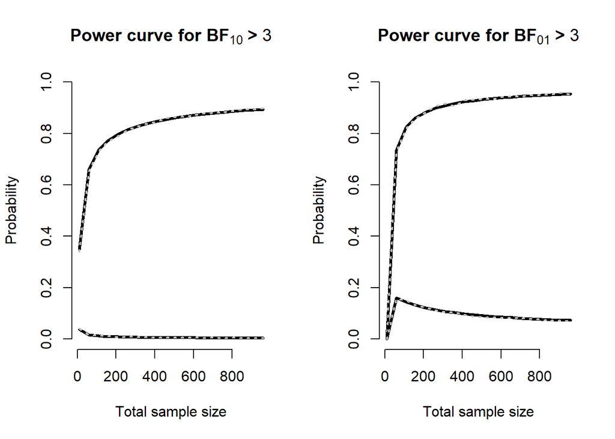

```r
  par(mfrow = c(1, 2))
  plot(sample_size, numeric_ones[,1],
       type       = "l",
       xlab       = "Total sample size",
       ylab       = "Probability",
       ylim       = c(0,1),
       frame.plot = FALSE,
       lwd        = 3,
       main       = bquote(bold("Power curve for BF"[10]~">"~.(threshold))))
  lines(sample_size, simulated[,1],    col = "gray",  lwd = 2, lty = 3)
  lines(sample_size, numeric_ones[,2], col = "black", lwd = 3)
  lines(sample_size, simulated[,2],    col = "grey",  lwd = 2, lty = 3)

  plot(sample_size, numeric_ones[,3],
       type       = "l",
       xlab       = "Total sample size",
       ylab       = "Probability",
       ylim       = c(0,1),
       frame.plot = FALSE,
       lwd        = 3,
       main       = bquote(bold("Power curve for BF"[0][1]~">"~.(threshold))))
  lines(sample_size, simulated[,3],    col = "gray",  lwd = 2, lty = 3)
  lines(sample_size, numeric_ones[,4], col = "black", lwd = 3)
  lines(sample_size, simulated[,4],    col = "grey",  lwd = 2, lty = 3)
```

### Independent samples t-tests (equal variance)

The simulation process is largely the same as that used for a one-sample $t$-test, except for the step involving the simulation of the $t$-values.

#### Setting up the simulation

Users can specify the parameters below for the simulation and call the function `BFpower.ttest.TwoSample` for input validation checks before proceeding with the simulation.

```r
# number of iterations
iter <- 5000

# specification of analysis and design priors
# Note:
#   Arguments 'dff' and 'dff_d' are only used when the corresponding prior is
#   "t-distribution".
alternative    <- "two.sided"; ROPE <- NULL
prior_analysis <- "Normal"; location   <- 0; scale   <- .707; dff   <- 3
prior_design   <- "Normal"; location_d <- 0; scale_d <- .707; dff_d <- .3
threshold       <- 3

 # input validation
results <-BFpower.ttest.TwoSample(
    alternative    = alternative,ROPE = ROPE,
    prior_analysis = prior_analysis, location   = location,   scale   = scale,   dff   = dff,
    prior_design   = prior_design,   location_d = location_d, scale_d = scale_d, dff_d = dff_d,
    threshold      = threshold,
    N1             = 50, # setting N1 and N2 to a scalar so that it calculates power for this sample size
    N2             = 50
)
```

#### Generating effect sizes - delta

A vector of quantiles is simulated first, and then it is converted back to delta.

```r
# -------------------------------
# CASE 1: Point Null
# -------------------------------

if (is.null(ROPE)) {

  delta_h0 <- rep(0, iter)
  bounds <- switch(alternative,
    "greater"   = c(0, Inf),
    "less"      = c(-Inf, 0),
    "two.sided" = c(-Inf, Inf)
  )
 delta_h1 <- draw_trunc(
    iter,
    lower    = bounds[1],
    upper    = bounds[2],
    prior    = prior_design,
    location = location_d,
    scale    = scale_d,
    dff      = dff_d
    )
}

# -------------------------------
# CASE 2: Interval Null
# -------------------------------

if (!is.null(ROPE)) {

  # -------- H0 --------
  # Note:
  #   For interval Bayes factor, the null has the same analysis prior as the H1.
  #   However, the delta under H1 makes use of the design prior.

  if (length(ROPE) == 2) {

    delta_h0 <- draw_trunc(
      iter,
      lower    = min(ROPE),
      upper    = max(ROPE),
      prior    = prior_analysis,
      location = location,
      scale    = scale,
      dff      = dff
      )

  } else {

    if (alternative == "greater") {
      delta_h0 <- draw_trunc(
        iter,
        lower    = 0,
        upper    = ROPE,
        prior    = prior_analysis,
        location = location,
        scale    = scale,
        dff      = dff
        )

    } else {
      delta_h0 <- draw_trunc(
        iter,
        lower    = ROPE,
        upper    = 0,
        prior    = prior_analysis,
        location = location,
        scale    = scale,
        dff      = dff)
    }
  }

  # -------- H1 --------

    if (length(ROPE) == 2) {

      # Division of iterations for two truncated distributions based on the tail probabilities
      lower <- min(ROPE)
      upper <- max(ROPE)

      p_lower <- cdf_fun(lower, prior_design, location_d, scale_d, dff_d)
      p_upper <- cdf_fun(upper, prior_design, location_d, scale_d, dff_d)

      mass_lower <- p_lower
      mass_upper <- 1 - p_upper

      n_upper <- round(iter * mass_upper / (mass_lower + mass_upper))
      n_lower <- iter - n_upper

      delta_h1 <- c(
        draw_trunc(n_upper, upper, Inf, prior_design, location_d, scale_d, dff_d),
        draw_trunc(n_lower, -Inf, lower, prior_design, location_d, scale_d, dff_d)
      )

    } else {

      if (alternative == "greater") {
        delta_h1 <- draw_trunc(
          iter,
          lower    = ROPE,
          upper    = Inf,
          prior    = prior_design,
          location = location_d,
          scale    = scale_d,
          dff      = dff_d)

      } else {
        delta_h1 <- draw_trunc(
          iter,
          lower    = -Inf,
          upper    = ROPE,
          prior    = prior_design,
          location = location_d,
          scale    = scale_d,
          dff      = dff_d)
      }
    }
  }
```

#### Generating data and computing the operational characteristics of the test

Based on the simulated delta under $\mathcal{H}_0$ and $\mathcal{H}_1$, the prior predictive distributions of $t$-values are obtained for a vector of sample sizes. The four rates (true positive, false positive, true negative, and false negative) are calculated based on the frequencies of $t$-values falling inside or outside the regions defined by the critical $t$-values, divided by the number of iterations. The numeric results are also obtained.

```r
 sample_size      <- seq(10,1000,50)
 r                <- 1    # ratio of sample size n2/n1
 simulated        <- array(NA, dim=c(length(sample_size),4))
 numeric_ones     <- array(NA, dim=c(length(sample_size),4))
 total            <- array(NA, dim = length(sample_size))
 for (i in 1:length(sample_size)){
  n1       <- sample_size[i]
  n2       <- n1*r
  total[i] <- n1 + n2

  df  <- n1 + n2 - 2
  ess <- (n1 * n2)/(n1 + n2)

  # simulate t statistics
  tval_h0 <- rt(iter, df, ncp = sqrt(ess) * delta_h0)
  tval_h1 <- rt(iter, df, ncp = sqrt(ess) * delta_h1)

  # critical t-values
  # Note:
  #   We made use of the t.cri to find how many BF10>k and BF01>k.
  #   We did not calculate BF for every t-value to speed thing up.
  suppressWarnings(
  if(is.null(ROPE)){
  t.cri.h1 <- BayesPower:::t2_BF10_bound(
    threshold, n1, r,
    prior_analysis, location, scale, dff,
    alternative)
  t.cri.h0 <- BayesPower:::t2_BF01_bound(
    threshold, n1,r,
    prior_analysis, location, scale, dff,
    alternative)
  } else{

  t.cri.h1 <- BayesPower:::t2e_BF10_bound(
    threshold, n1,r,
    prior_analysis, location, scale, dff,
    alternative, ROPE)
  t.cri.h0 <- BayesPower:::t2e_BF01_bound(
    threshold, n1,r,
    prior_analysis, location, scale, dff,
    alternative,ROPE)

  }
  )
  # operational characteristics
  TPR <- switch(alternative,
                   "two.sided" = mean(tval_h1 > max(t.cri.h1) | tval_h1 < min(t.cri.h1)),
                   "greater"   = mean(tval_h1 > max(t.cri.h1)),
                   "less"      = mean(tval_h1 < max(t.cri.h1)))
  FPR <- switch(alternative,
                   "two.sided" = mean(tval_h0 > max(t.cri.h1) | tval_h0 < min(t.cri.h1)),
                   "greater"   = mean(tval_h0 > max(t.cri.h1)),
                   "less"      = mean(tval_h0 < max(t.cri.h1)))

 if (any(t.cri.h0 == "bound cannot be found")) {

  TNR <- 0
  FNR <- 0

} else {

  TNR <- switch(alternative,
    "two.sided" = mean(tval_h0 < max(t.cri.h0) & tval_h0 > min(t.cri.h0)),
    "greater"   = mean(tval_h0 < max(t.cri.h0)),
    "less"      = mean(tval_h0 > min(t.cri.h0))
  )

  FNR <- switch(alternative,
    "two.sided" = mean(tval_h1 < max(t.cri.h0) & tval_h1 > min(t.cri.h0)),
    "greater"   = mean(tval_h1 < max(t.cri.h0)),
    "less"      = mean(tval_h1 > min(t.cri.h0))
  )
}


 simulated[i,] <- c(TPR,FPR,TNR,FNR)

 numeric_results<- BFpower.ttest.TwoSample(
      alternative    = alternative,ROPE = ROPE,
      prior_analysis = prior_analysis, location   = location,     scale   = scale,
      dff            = dff,
      prior_design   = prior_design,   location_d = location_d,   scale_d = scale_d,
      dff_d          = dff_d,
      threshold      = threshold,
      N1             = n1,
      N2             = n2)

 numeric_ones[i,] <-  c(numeric_results$results[[1]],
                        numeric_results$results[[4]],
                        numeric_results$results[[3]],
                        numeric_results$results[[2]])
}
```

#### Plotting the results.

**Plot Legend Description**:

- **Black solid lines**: Numeric values
- **Gray dotted lines**: Simulated values

**Line positions**:

- **Top lines**:
  - Left: True Positive
  - Right: True Negative
- **Lower lines**:
  - Left: False Positive
  - Right: False Negative

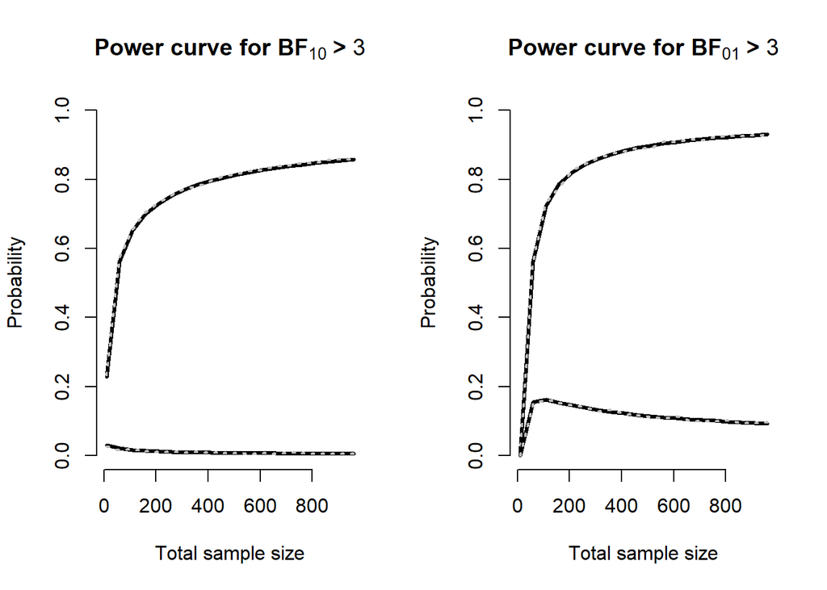

```r
  par(mfrow = c(1, 2))
  plot(sample_size, numeric_ones[,1],
       type       = "l",
       xlab       = "Total sample size",
       ylab       = "Probability",
       ylim       = c(0,1),
       frame.plot = FALSE,
       lwd        = 3,
       main       = bquote(bold("Power curve for BF"[10]~">"~.(threshold))))
  lines(sample_size, simulated[,1],    col = "gray",  lwd = 2, lty = 3)
  lines(sample_size, numeric_ones[,2], col = "black", lwd = 3)
  lines(sample_size, simulated[,2],    col = "grey",  lwd = 2, lty = 3)

  plot(sample_size, numeric_ones[,3],
       type       = "l",
       xlab       = "Total sample size",
       ylab       = "Probability",
       ylim       = c(0,1),
       frame.plot = FALSE,
       lwd        = 3,
       main       = bquote(bold("Power curve for BF"[0][1]~">"~.(threshold))))
  lines(sample_size, simulated[,3],    col = "gray",  lwd = 2, lty = 3)
  lines(sample_size, numeric_ones[,4], col = "black", lwd = 3)
  lines(sample_size, simulated[,4],    col = "grey",  lwd = 2, lty = 3)
```

### Bivariate Correlation

#### Setting up the simulation

Users can specify the parameters below for the simulation and call the function `BFpower.cor` for input validation checks before proceeding with the simulation.

```r
# number of iterations
iter <- 5000

# specification of analysis and design priors
# Note:
#   Arguments 'k',  'alpha', 'beta' and 'scale' for the analysis prior and the ones for the design prior (e.g., 'k_d') are only used for the corresponding priors.
alternative    <- "greater"; h0  <- 0;  ROPE    <- .2
prior_analysis <- "beta";    k   <- 1; alpha    <- 1; beta   <- 1; scale   <- .5
prior_design   <- "beta";    k_d <- 2; alpha_d  <- 2; beta_d <- 2; scale_d <- .3;
location_d     <- .3;
threshold      <- 3

 # input validation
results <- BFpower.cor(
  alternative    = alternative,    h0  = h0, ROPE   = ROPE,
  prior_analysis = prior_analysis, k   = k  ,alpha   = alpha  , beta   = beta,
  scale          = scale,
  prior_design   = prior_design ,  k_d = k_d,alpha_d = alpha_d, beta_d = beta_d,
  scale_d        = scale_d,
  location_d     = location_d,
  N              = 50, # setting N to a scalar so that it calculates power for this sample size
  threshold      = threshold)
```

#### Generating effect sizes - rho

A vector of quantiles is simulated first, and then it is converted back to rho.

```r
# -------------------------------
# Helper functions
# -------------------------------

cdf_fun <- function(x, prior, k,alpha,beta,location,scale) {
  switch(prior,
    "d_beta"    =  pBeta_ab(x,shape1 = 1/k,shape2 = 1/k,a = -1,b = 1),
    "Moment"    =  BayesPower:::pmom(x-location,tau = scale^2),
    "beta"      =  pBeta_ab(x,shape1 = alpha,shape2 = beta,a = -1,b = 1)
  )
}

q_fun <- function(p,  prior, k,alpha,beta,location,scale) {
  switch(prior,
    "d_beta"   =   qBeta_ab(p,shape1 = 1/k,shape2 = 1/k,a = -1,b = 1),
    "Moment"   =   BayesPower:::qmom(p, tau = scale^2)+h0,
    "beta"     =   qBeta_ab(p,shape1 = alpha,shape2 = beta,a =-1,b = 1)
  )
}

draw_trunc <- function(n, lower, upper, prior, k,alpha,beta,location,scale) {
  if (prior == "Point") return(rep(location, iter))
  p_lower <- cdf_fun(lower, prior,k,alpha,beta,location, scale)
  p_upper <- cdf_fun(upper, prior, k,alpha,beta,location, scale)
  u       <- runif(n, p_lower, p_upper)
  q_fun(u, prior, k,alpha,beta,location,scale)
}

# -------------------------------
# CASE 1: Point Null
# -------------------------------

if (is.null(ROPE)) {
  rho_h0 <- rep(h0, iter)
  bounds <- switch(alternative,
    "greater"   = c(h0, 1),
    "less"      = c(-1, h0),
    "two.sided" = c(-1, 1))

  rho_h1 <- draw_trunc(
    iter,
    lower    = bounds[1],
    upper    = bounds[2],
    prior    = prior_design,
    k        = k_d,
    alpha    = alpha_d,
    beta     = beta_d,
    location = location_d,
    scale    = scale_d)

}

# -------------------------------
# CASE 2: Interval Null
# -------------------------------

if (!is.null(ROPE)) {

  # -------- H0 --------
  # Note:
  #   For interval Bayes factor, the null has the same analysis prior as the H1.
  #   However, the delta under H1 makes use of the design prior.

  if (length(ROPE) == 2) {

    rho_h0   <- draw_trunc(
      iter,
      lower     = min(ROPE),
      upper     = max(ROPE),
      prior     = prior_analysis,
      k         = k,
      alpha     = alpha,
      beta      = beta,
      location  = h0,
      scale     = scale)

  } else {

    if (alternative == "greater") {

      rho_h0   <- draw_trunc(
        iter,
        lower    = h0,
        upper    = h0 + ROPE,
        prior    = prior_analysis,
        k        = k,
        alpha    = alpha,
        beta     = beta,
        location = h0,
        scale    = scale_d)


    } else {
      rho_h0   <- draw_trunc(
        iter,
        lower    = h0 + ROPE,
        upper    = h0,
        prior    = prior_analysis,
        k        = k,
        alpha    = alpha,
        beta     = beta,
        location = location,
        scale    = scale)
    }
  }

  # -------- H1 --------


  if (length(ROPE) == 2) {

    # Division of iterations for two truncated distributions based on the tail probabilities
    lower   <- h0 + min(ROPE)
    upper   <- h0 + max(ROPE)
    rho_h0  <- draw_trunc(
      iter,
      lower    = lower,
      upper    = upper,
      prior    = prior_design,
      k        = k_d,
      alpha    = alpha_d,
      beta     = beta_d,
      location = location_d,
      scale    = scale_d)

      p_lower <- cdf_fun(lower, prior_design, k_d, alpha_d,beta_d,location_d,scale_d)
      p_upper <- cdf_fun(upper, prior_design, k_d, alpha_d,beta_d,location_d,scale_d)

      mass_lower <- p_lower
      mass_upper <- 1 - p_upper

      n_upper <- round(iter * mass_upper / (mass_lower + mass_upper))
      n_lower <- iter - n_upper

      rho_h1 <- c(draw_trunc(n_upper,
                             lower      = upper,
                             upper      = 1,
                             prior      = prior_design,
                             k          = k_d,
                             alpha      = alpha_d,
                             beta       = beta_d,
                             location   = location_d,
                             scale      = scale_d),
                  draw_trunc(n_lower,
                             lower      = -1,
                             upper      = lower,
                             prior      = prior_design,
                             k          = k_d,
                             alpha      = alpha_d,
                             beta       = beta_d,
                             location   = location_d,
                             scale      = scale_d))


    } else {

      if (alternative == "greater") {
        rho_h1 <- draw_trunc(
          iter,
          lower     = h0 + ROPE,
          upper     = 1,
          prior     = prior_design,
          k         = k_d,
          alpha     = alpha_d,
          beta      = beta_d,
          location  = location_d,
          scale     = scale_d)

      } else {
        rho_h1 <- draw_trunc(
          iter,
          lower    = -1,
          upper    = h0+ROPE,
          prior    = prior_design,
          k        = k_d,
          alpha    = alpha_d,
          beta     = beta_d,
          location = location_d,
          scale    = scale_d)
      }
    }
  }
```

#### Generating data and computing the operational characteristics of the test

Based on the simulated rho under $\mathcal{H}_0$ and $\mathcal{H}_1$, the prior predictive distributions of sampled correlations are obtained for a vector of sample sizes. The four rates (true positive, false positive, true negative, and false negative) are calculated based on the frequencies of sampled correlations falling inside or outside the regions defined by the critical $r$-values, divided by the number of iterations. The numeric results are also obtained.

```r
 sample_size  <- seq(10,1000,50)
 simulated    <- array(NA, dim=c(length(sample_size),4))
 numeric_ones <- array(NA, dim=c(length(sample_size),4))

 # the location parameter of the analysis prior is always equal to h0
 location <- h0

 for (i in 1:length(sample_size)){
  N <- sample_size[i]
  # --- simulate r  ---
  rval_h0 <- sapply(1:iter, function(i) {
    r     <- rho_h0[i]
    Sigma <- matrix(c(1, r,
                      r, 1), nrow = 2, byrow = TRUE)
    # mean vector
    mu    <- rep(0, 2)
    # generate multivariate normal
    X     <- rmvnorm(N, mean = mu, sigma = Sigma)
    # correlation between first two columns
    cor(X)[1, 2]
  })
  rval_h1 <- sapply(1:iter, function(i) {
    r     <- rho_h1[i]
    Sigma <- matrix(c(1, r,
                      r, 1), nrow = 2, byrow = TRUE)
    # mean vector
    mu    <- rep(0, 2)
    # generate multivariate normal
    X     <- rmvnorm(N, mean = mu, sigma = Sigma)
    # correlation between first two columns
    cor(X)[1, 2]
  })

  # --- critical correlation ---
  # Note:
  #   We made use of the r.cri to find how many BF10>k and BF01>k.
  #   We did not calculate BF for every r to speed thing up.

   r.cri.h1 <- if (is.null(ROPE)){
     BayesPower:::r_BF_bound_10(threshold,N,k,
                                alpha,beta,h0,alternative ,
                                location,scale ,1 , prior_analysis)
     }else{
    BayesPower:::re_BF_bound_10(threshold,N,k,
                                alpha,beta,h0,alternative,
                                location,scale ,dff ,prior_analysis,ROPE)}
   r.cri.h0 <- if (is.null(ROPE)){
     BayesPower:::r_BF_bound_01(threshold,N,k,
                                alpha,beta,h0,alternative ,
                                location,scale ,1 , prior_analysis )
     } else {
    BayesPower:::re_BF_bound_01(threshold,N,k,
                                alpha,beta,h0,alternative ,
                                location,scale ,1 ,prior_analysis,ROPE)}


  # --- operational characteristics ---
   TPR <- switch(alternative,
                   "two.sided" = mean(rval_h1 > max(r.cri.h1) | rval_h1 < min(r.cri.h1)),
                   "greater"   = mean(rval_h1 > max(r.cri.h1)),
                   "less"      = mean(rval_h1 < max(r.cri.h1)))
   FPR <- switch(alternative,
                   "two.sided" = mean(rval_h0 > max(r.cri.h1) | rval_h0 < min(r.cri.h1)),
                   "greater"   = mean(rval_h0 > max(r.cri.h1)),
                   "less"      = mean(rval_h0 < max(r.cri.h1)))

   if (any(r.cri.h0 == "bound cannot be found")){
    TNR <- FNR <- 0
  } else {
  TNR <- switch(alternative,
                "two.sided" = mean(rval_h0 < max(r.cri.h0) & rval_h0 > min(r.cri.h0)),
                "greater"   = mean(rval_h0 < max(r.cri.h0)),
                "less"      = mean(rval_h0 > max(r.cri.h0)))
  FNR <- switch(alternative,
                "two.sided" = mean(rval_h1 < max(r.cri.h0) & rval_h1 > min(r.cri.h0)),
                "greater"   = mean(rval_h1 < max(r.cri.h0)),
                "less"      = mean(rval_h1 > max(r.cri.h0)))
  }
 simulated[i,] <- c(TPR,FPR,TNR,FNR)

 numeric_results<- BFpower.cor(
  alternative    = alternative,    h0  = h0, ROPE = ROPE,
  prior_analysis = prior_analysis, k   = k,  alpha   = alpha,   beta   = beta,  scale   = scale,
  prior_design   = prior_design,   k_d = k_d,alpha_d = alpha_d, beta_d = beta_d,scale_d = scale_d,
  location_d     = location_d,
  N              = N,
  threshold      = threshold)

 numeric_ones[i,] <-  c(numeric_results$results[[1]],
                        numeric_results$results[[4]],
                        numeric_results$results[[3]],
                        numeric_results$results[[2]])
}
```

#### Plotting the results.

**Plot Legend Description**:

- **Black solid lines**: Numeric values
- **Gray dotted lines**: Simulated values

**Line positions**:

- **Top lines**:
  - Left: True Positive
  - Right: True Negative
- **Lower lines**:
  - Left: False Positive
  - Right: False Negative

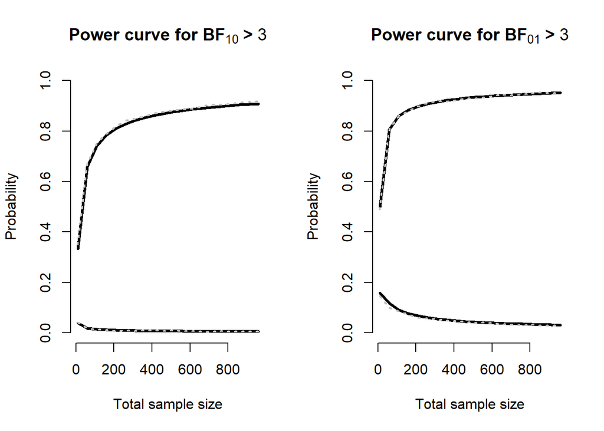

```r
  par(mfrow = c(1, 2))
  plot(sample_size, numeric_ones[,1],
       type       = "l",
       xlab       = "Total sample size",
       ylab       = "Probability",
       ylim       = c(0,1),
       frame.plot = FALSE,
       lwd        = 3,
       main       = bquote(bold("Power curve for BF"[10]~">"~.(threshold))))
  lines(sample_size, simulated[,1],    col = "gray",  lwd = 2, lty = 3)
  lines(sample_size, numeric_ones[,2], col = "black", lwd = 3)
  lines(sample_size, simulated[,2],    col = "grey",  lwd = 2, lty = 3)


  plot(sample_size, numeric_ones[,3],
       type       = "l",
       xlab       = "Total sample size",
       ylab       = "Probability",
       ylim       = c(0,1),
       frame.plot = FALSE,
       lwd        = 3,
       main       = bquote(bold("Power curve for BF"[0][1]~">"~.(threshold))))
  lines(sample_size, simulated[,3],    col = "gray",  lwd = 2, lty = 3)
  lines(sample_size, numeric_ones[,4], col = "black", lwd = 3)
  lines(sample_size, simulated[,4],    col = "grey",  lwd = 2, lty = 3)
```

### Regression/ANOVA

#### Setting up the simulation

Users can specify the parameters below for the simulation and call the function `BFpower.f.test` for input validation checks before proceeding with the simulation.

```r
# number of iterations
iter <- 1000

# specification of analysis and design prior
# Note:
#   Arguments 'rscale' and 'rscale_d' are only used when the corresponding prior is
#   "Moment".
threshold      <-  3          ; p     <- 3; k        <- 5
prior_analysis <- "effectsize"; dff   <- 5; rscale   <- .18; f_m   <- sqrt(.1)
prior_design   <- "effectsize"; dff_d <- 3; rscale_d <- .15; f_m_d <- sqrt(.1)
ROPE           <-  NULL

# the number of additional predictors
q  <- k - p

# input validation
results <- BFpower.f.test(
  threshold      = threshold,      p     = p,    k        = k,
  prior_analysis = prior_analysis, dff   = dff,  rscale   = rscale,  f_m   = f_m,
  prior_design   = prior_design ,  dff_d = dff_d,rscale_d = rscale_d,f_m_d = f_m_d,
  N              = 100 ,
  ROPE           = ROPE
)
```

#### Generating effect sizes - squared f

The R functions for the density functions, cumulative distribution functions, and inverse quantile functions for the priors are defined as follows:

```r
# density function of effect size prior
d_fes <- function(fsq, q, dff, rscale, f_m) {
  gamma((q + dff) / 2) / (gamma(dff / 2) * gamma(q / 2)) *
    (dff * rscale^2)^(dff / 2) * fsq^(q / 2 - 1) *
    (dff * rscale^2 + f_m^2 + fsq)^(-dff / 2 - q / 2) *
    hypergeo::genhypergeo(
      c((dff + q) / 4, (2 + dff + q) / 4),
      q / 2,
      4 * f_m^2 * fsq / (dff * rscale^2 + f_m^2 + fsq)^2
    )
}
# cumulative distribution function of effect size prior
p_fes <- function(fsq, q, dff, rscale, f_m) {
  sapply(fsq, function(x) {
    if (x == 0) {
      return(0)  # probability is 0 if fsq = 0
    } else if (is.infinite(x)) {
      return(1)  # probability is 1 if fsq = Inf
    } else {
      integrate(
        d_fes,
        lower         = 0,
        upper         = x,
        q             = q,
        dff           = dff,
        rscale        = rscale,
        f_m           = f_m,
        rel.tol       = 1e-10,
        stop.on.error = FALSE
      )$value
    }
  })
}
# inverse of cumulative distribution function of effect size prior

q_fes <- function(p, q, dff, rscale, f_m) {
  sapply(p, function(prob) {
    if (prob == 0) return(0)
    if (prob == 1) return(Inf)
    objfun <- function(fsq) {
      p_fes(fsq, q, dff, rscale, f_m)- prob}

    opt    <- uniroot(objfun,lower=0,upper=5000)$root
    return(opt)
  })
}

# density function of moment prior
d_fmoment<-function(fsq,q,dff,f_m){
  temp <- f_m^2 * (dff + q - 2)/2
  gamma((q + dff) / 2) / gamma(dff / 2) / gamma(q / 2) *
    2 * (dff - 2) / q / (dff-2 + q) / f_m^2 *
    fsq^(q/2) * temp^(dff/2) * (temp + fsq)^(-(dff+q)/2)
}
# cumulative distribution function of moment prior

p_fmoment <- function(fsq, q, dff, f_m) {
  sapply(fsq, function(x) {
    integrate(
      d_fmoment,
      lower         = 0,
      upper         = x,
      q             = q,
      dff           = dff,
      f_m           = f_m,
      rel.tol       = 1e-10,
      stop.on.error = F
    )$value
  })
}
# inverse of cumulative distribution function of moment prior

q_fmoment <- function(p, q, dff, f_m) {
  sapply(p, function(prob) {
    if (prob == 0) return(0)
    if (round(prob,10) == 1) return(Inf)
    objfun <- function(fsq) {
      p_fmoment(fsq, q, dff, f_m)- prob
      }

    # give a wider search space
    opt <- uniroot(objfun,lower=0,upper=5000)$root
    return(opt)
  })
}
```

A vector of quantile is simulated first, then it is converted back to squared f.

```r
# -------------------------------
# Helper functions
# -------------------------------

cdf_fun <- function(x, prior, q, dff, rscale, f_m) {
  switch(prior,
         "effectsize" = p_fes(x, q, dff, rscale, f_m),
         "Moment"     = p_fmoment(x, q, dff,  f_m))
}

q_fun <- function(p,  prior, q, dff, rscale, f_m) {
  switch(prior,
         "effectsize"   = q_fes(p, q, dff, rscale, f_m),
         "Moment"       = q_fmoment(p, q, dff,  f_m)
  )
}
draw_trunc <- function(n, lower, upper, prior, q, dff, rscale, f_m) {
  if(prior == "Point"){return(rep(f_m^2,iter))}
  p_lower <- if(lower == 0) 0 else {cdf_fun(lower, prior, q, dff, rscale, f_m)}
  p_upper <- if(upper == Inf) 1 else { cdf_fun(upper, prior, q, dff, rscale, f_m)}
  u       <- runif(n, p_lower, p_upper)
  q_fun(u, prior, q, dff, rscale, f_m)
}

# -------------------------------
# CASE 1: Point Null
# -------------------------------

if (is.null(ROPE)) {

  fsq_h0 <- rep(0, iter)
  fsq_h1 <- draw_trunc(iter, 0, Inf, prior_design, q,dff_d, rscale_d, f_m_d)

}

# -------------------------------
# CASE 2: Interval Null
# -------------------------------

if (!is.null(ROPE)) {
  fsq_h0 <- draw_trunc(iter, 0, ROPE, prior_analysis, q,dff, rscale, f_m)
  fsq_h1 <- draw_trunc(iter, ROPE, Inf, prior_design, q,dff_d, rscale_d, f_m_d)
}
```

#### Generating data and computing the operational characteristics of the test

Based on the simulated squared $f$ under $\mathcal{H}_0$ and $\mathcal{H}_1$, the prior predictive distributions of $f$-values are obtained for a vector of sample sizes. The four rates (true positive, false positive, true negative, and false negative) are calculated based on the frequencies of the $f$-values falling inside or outside the regions defined by the critical $f$-values, divided by the number of iterations. The numeric results are also obtained.

```r
# the minimal sample size should be 2*k-p+1

 sample_size  <- seq(2*k-p+2,1000,50)
 simulated    <- array(NA, dim=c(length(sample_size),4))
 numeric_ones <- array(NA, dim=c(length(sample_size),4))

 for (i in 1:length(sample_size)){
  n  <- sample_size[i]
  q  <-  k - p
  m  <-  n - p

  # --- simulate f-values  ---
  fval_h0  <- sapply(1:iter, function(ii) {rf(1, q, n - k, m * fsq_h0[ii])})
  fval_h1  <- sapply(1:iter, function(ii) {rf(1, q, n - k, m * fsq_h1[ii])})

  # --- critical f-values ---
  # Note:
  #   We made use of the f.cri to find how many BF10>k and BF01>k.
  #   We did not calculate BF for every f-value to speed thing up.

  f.cri.h1 <- if(is.null(ROPE)) {
    BayesPower:::F_BF_bound_10(threshold, q, m, dff, rscale, f_m, prior_analysis)
    } else {
    BayesPower:::Fe_BF_bound_10(threshold, q, m, dff, rscale, f_m, prior_analysis ,ROPE)}

  f.cri.h0 <- if(is.null(ROPE)) {
    BayesPower:::F_BF_bound_01(threshold, q, m, dff, rscale, f_m, prior_analysis)
    } else {
    BayesPower:::Fe_BF_bound_01(threshold, q, m, dff, rscale, f_m, prior_analysis ,ROPE)}

  # --- operational characteristics ---
   TPR <- sum(fval_h1>=f.cri.h1)/iter
   FPR <- sum(fval_h0>=f.cri.h1)/iter
 # Check if f.cri.h0 is valid
 if (is.character(f.cri.h0) && f.cri.h0 == "no bound is found") {
  TNR <- 0
  FNR <- 0
  } else {
  # regular calculation
  TNR <- sum(fval_h0 <= f.cri.h0) / iter
  FNR <- sum(fval_h1 <= f.cri.h0) / iter
}

 simulated[i,] <- c(TPR,FPR,TNR,FNR)
 numeric_results<-  BFpower.f.test(
  threshold      = threshold,     p     = p,     k        = k,
  prior_analysis = prior_analysis,dff   = dff,   rscale   = rscale,  f_m   = f_m,
  prior_design   = prior_design , dff_d = dff_d, rscale_d = rscale_d,f_m_d = f_m_d,
  N              = n,
  ROPE           = ROPE)

 numeric_ones[i,] <-  c(numeric_results$results[[1]],
                        numeric_results$results[[4]],
                        numeric_results$results[[3]],
                        numeric_results$results[[2]])
}
```

#### Plotting the results.

**Plot Legend Description**:

- **Black solid lines**: Numeric values
- **Gray dotted lines**: Simulated values

**Line positions**:

- **Top lines**:
  - Left: True Positive
  - Right: True Negative
- **Lower lines**:
  - Left: False Positive
  - Right: False Negative

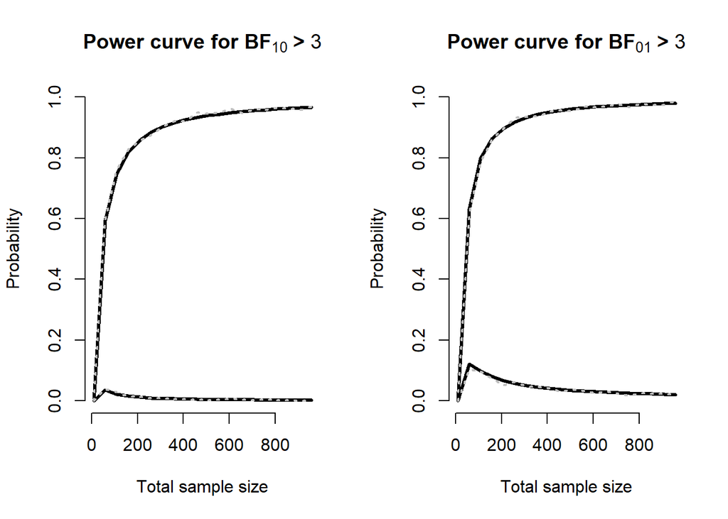

```r
  par(mfrow = c(1, 2))
  plot(sample_size, numeric_ones[,1],
       type       = "l",
       xlab       = "Total sample size",
       ylab       = "Probability",
       ylim       = c(0,1),
       frame.plot = FALSE,
       lwd        = 3,
       main       = bquote(bold("Power curve for BF"[10]~">"~.(threshold))))
  lines(sample_size, simulated[,1],    col = "gray",  lwd = 2, lty = 3)
  lines(sample_size, numeric_ones[,2], col = "black", lwd = 3)
  lines(sample_size, simulated[,2],    col = "grey",  lwd = 2, lty = 3)


  plot(sample_size, numeric_ones[,3],
       type       = "l",
       xlab       = "Total sample size",
       ylab       = "Probability",
       ylim       = c(0,1),
       frame.plot = FALSE,
       lwd        = 3,
       main       = bquote(bold("Power curve for BF"[0][1]~">"~.(threshold))))
  lines(sample_size, simulated[,3],    col = "gray",  lwd = 2, lty = 3)
  lines(sample_size, numeric_ones[,4], col = "black", lwd = 3)
  lines(sample_size, simulated[,4],    col = "grey",  lwd = 2, lty = 3)
```

### One proportion

#### Setting up the simulation

Users can specify the parameters below for the simulation and call the function `BFpower.bin` for input validation checks before proceeding with the simulation.

```r
# number of iterations
iter <- 10000

# specification of analysis and design prior
# Note:
#   Arguments 'scale' , 'scale_d' and 'location_d' are only used when the corresponding prior is
#   "Moment".
alternative    <- "two.sided"; threshold  <- 3; h0     <- .5
prior_analysis <- "beta";      alpha      <- 1; beta   <- 1; scale   <- .25
prior_design   <- "beta";      alpha_d    <- 1; beta_d <- 2; scale_d <- .1; location_d <- .3
ROPE <- NULL

 # input validation
results <- BFpower.bin(
  alternative    = alternative,    threshold = threshold,h0     = h0,
  prior_analysis = prior_analysis, alpha     = alpha,    beta   = beta,  scale   = scale,
  prior_design   = prior_design,   alpha_d   = alpha_d,  beta_d = beta_d,scale_d = scale_d,location_d = location_d,
  N              = 50, # setting N to a scalar so that it calculates power for this sample size
  ROPE           = ROPE)
```

#### Generating effect sizes - theta

A vector of quantiles is simulated first, and then it is converted back to theta.

```r
# -------------------------------
# Helper functions
# -------------------------------
cdf_fun <- function(x, prior, location, scale, alpha, beta) {
  switch(prior,
         "Moment" = BayesPower:::pmom(x - location, tau = scale^2),
         "beta"   = pBeta_ab(x, shape1 = alpha, shape2 = beta, a = 0, b = 1)
  )
}

q_fun <- function(p, prior, location, scale, alpha, beta) {
  switch(prior,
         "Moment" = qmom(p, tau = scale^2) + location,
         "beta"   = qBeta_ab(p, shape1 = alpha, shape2 = beta, a = 0, b = 1)
  )
}

draw_trunc <- function(n, lower, upper, prior, location, scale, alpha, beta) {
  if (prior == "Point") return(rep(location, n))
  p_lower <- cdf_fun(lower, prior, location, scale, alpha, beta)
  p_upper <- cdf_fun(upper, prior, location, scale, alpha, beta)
  u       <- runif(n, p_lower, p_upper)
  q_fun(u, prior, location, scale, alpha, beta)
}
# -------------------------------
# CASE 1: Point Null
# -------------------------------

if (is.null(ROPE)) {
  theta_h0 <- rep(h0, iter)
  bounds   <- switch(alternative,
                   "greater"   = c(h0, 1),
                   "less"      = c(0, h0),
                   "two.sided" = c(0, 1)
  )
  theta_h1 <- draw_trunc(iter, min(bounds), max(bounds),prior_design, location_d, scale_d, alpha_d, beta_d)
}

# -------------------------------
# CASE 2: Interval Null
# -------------------------------

if (!is.null(ROPE)) {

  # -------- H0 --------
  # Note:
  #   For interval Bayes factor, the null has the same analysis prior as the H1.
  #   However, the delta under H1 makes use of the design prior.

  if (length(ROPE) == 2) {

     theta_h0 <- draw_trunc(iter, h0 + min(ROPE), h0 + max(ROPE),prior_analysis, h0, scale, alpha, beta)

  } else {

    if (alternative == "greater") {
      theta_h0 <- draw_trunc(iter, h0, h0 + ROPE,prior_analysis, h0, scale, alpha, beta)
    }
    if (alternative == "less"){
      theta_h0 <- draw_trunc(iter, h0 + ROPE, h0,prior_analysis, h0, scale, alpha, beta)

}
  }
  # -------- H1 --------

  if (length(ROPE) == 2) {

    # Division of iterations for two truncated distributions based on the tail probabilities
    lower <- h0 + min(ROPE)
    upper <- h0 + max(ROPE)

    p_lower <- cdf_fun(lower, prior_design,location_d, scale_d, alpha_d, beta_d)
    p_upper <- cdf_fun(upper, prior_design,location_d, scale_d, alpha_d, beta_d)

    mass_lower <- p_lower
    mass_upper <- 1 - p_upper

    n_upper  <- round(iter * mass_upper / (mass_lower + mass_upper))
    n_lower  <- iter - n_upper

    theta_h1 <- c(draw_trunc(n_upper, upper, 1,prior_design,location_d, scale_d, alpha_d, beta_d),
                  draw_trunc(n_lower, 0, lower,prior_design,location_d, scale_d, alpha_d, beta_d))

  } else {

    if (alternative == "greater") {
      theta_h1 <- draw_trunc(iter,h0+ROPE, 1,prior_design,location_d, scale_d, alpha_d, beta_d)

    } else {
      theta_h1 <- draw_trunc(iter,0, h0+ROPE,prior_design,location_d, scale_d, alpha_d, beta_d)
    }
  }
}
```

#### Generating data and computing the operational characteristics of the test

Based on the simulated theta under $\mathcal{H}_0$ and $\mathcal{H}_1$, the prior predictive distributions of the number of successes per group are obtained for a vector of sample sizes. The four rates (true positive, false positive, true negative, and false negative) are calculated based on the frequencies of the Bayes factors. The numeric results are also obtained.

```r
 sample_size  <- seq(10,1000,50)
 simulated    <- array(NA, dim=c(length(sample_size),4))
 numeric_ones <- array(NA, dim=c(length(sample_size),4))
 for (i in 1:length(sample_size)){
  n <- sample_size[i]

  # --- simulate number of success ---
  suc_h0 <-  sapply(1:iter, function(ii) {rbinom(1,n,theta_h0[ii])})
  suc_h1 <-  sapply(1:iter, function(ii) {rbinom(1,n,theta_h1[ii])})

  # --- operational characteristics ---
   BF10_h0 <-  sapply(1:iter, function(ii) {
   # BF10.bin.test(suc_h0[ii],n, alpha,beta,h0,scale,
   #                      prior_analysis,alternative,ROPE)$bf10

   # we use the BF function from the backend code instead of
   # the exported one to speed thing up
    if(is.null(ROPE)) {
      BayesPower:::bin_BF(suc_h0[ii],n,alpha,beta,h0,scale,prior_analysis,alternative)
    } else{
      BayesPower:::bin_e_BF(suc_h0[ii],n,alpha,beta,h0,scale,prior_analysis,alternative,ROPE)
    }
  })
   BF10_h1 <-  sapply(1:iter, function(ii) {
   #BF10.bin.test(suc_h1[ii],n, alpha,beta,h0,scale,
   #                     prior_analysis,alternative,ROPE)$bf10
     if(is.null(ROPE)) {
        BayesPower:::bin_BF(suc_h1[ii],n,alpha,beta,h0,scale,prior_analysis,alternative)
    } else{

      BayesPower:::bin_e_BF(suc_h1[ii],n,alpha,beta,h0,scale,prior_analysis,alternative,ROPE)
    }
  })

  # --- operational characteristics ---
  TPR <- sum(BF10_h1>=threshold)/iter
  FPR <- sum(BF10_h0>=threshold)/iter

  TNR <- sum((1/BF10_h0)>=threshold)/iter
  FNR <- sum((1/BF10_h1)>=threshold)/iter


 simulated[i,] <- c(TPR,FPR,TNR,FNR)

 numeric_results<- BFpower.bin(
  alternative    = alternative,    threshold = threshold,h0     = h0,
  prior_analysis = prior_analysis, alpha     = alpha,    beta   = beta,  scale   = scale,
  prior_design   = prior_design,   alpha_d   = alpha_d,  beta_d = beta_d,scale_d = scale_d,location_d = location_d,
  N              = n,
  ROPE           = ROPE)

 numeric_ones[i,] <-  c(numeric_results$results[[1]],
                        numeric_results$results[[4]],
                        numeric_results$results[[3]],
                        numeric_results$results[[2]])
}
```

#### Plotting the results.

**Plot Legend Description**:

- **Black solid lines**: Numeric values
- **Gray dotted lines**: Simulated values

**Line positions**:

- **Top lines**:
  - Left: True Positive
  - Right: True Negative
- **Lower lines**:
  - Left: False Positive
  - Right: False Negative

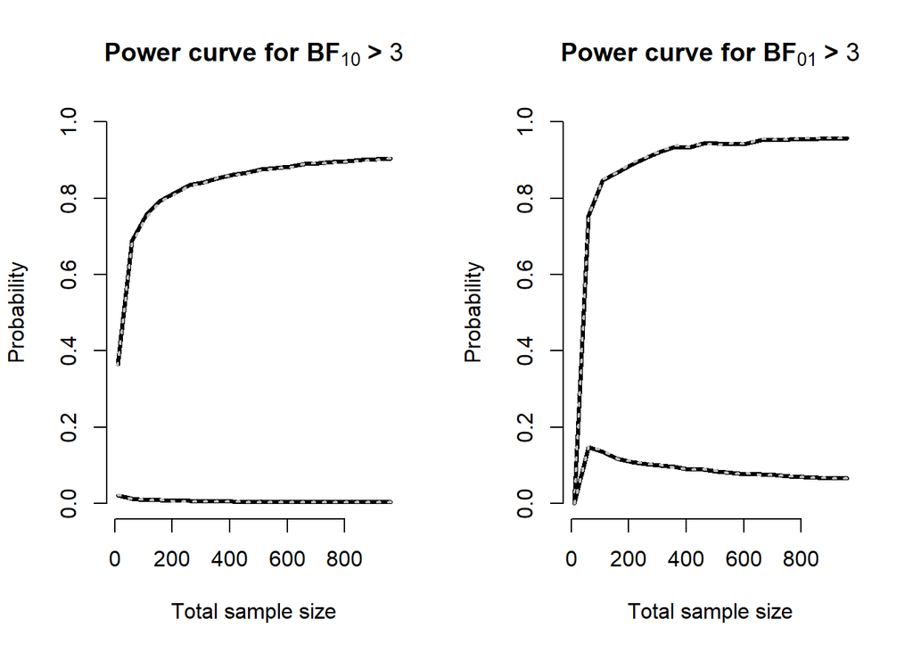

```r
  par(mfrow = c(1, 2))
  plot(sample_size, numeric_ones[,1],
       type       = "l",
       xlab       = "Total sample size",
       ylab       = "Probability",
       ylim       = c(0,1),
       frame.plot = FALSE,
       lwd        = 3,
       main       = bquote(bold("Power curve for BF"[10]~">"~.(threshold))))
  lines(sample_size, simulated[,1],    col = "gray",  lwd = 2, lty = 3)
  lines(sample_size, numeric_ones[,2], col = "black", lwd = 3)
  lines(sample_size, simulated[,2],    col = "grey",  lwd = 2, lty = 3)

  plot(sample_size, numeric_ones[,3],
       type       = "l",
       xlab       = "Total sample size",
       ylab       = "Probability",
       ylim       = c(0,1),
       frame.plot = FALSE,
       lwd        = 3,
       main       = bquote(bold("Power curve for BF"[0][1]~">"~.(threshold))))
  lines(sample_size, simulated[,3],    col = "gray",  lwd = 2, lty = 3)
  lines(sample_size, numeric_ones[,4], col = "black", lwd = 3)
  lines(sample_size, simulated[,4],    col = "grey",  lwd = 2, lty = 3)
```

### Two proportions

#### Setting up the simulation

Users can specify the parameters below for the simulation and call the function `BFpower.props` for input validation checks before proceeding with the simulation.

```r
# number of iterations
iter <- 5000

# Specification of analysis and design prior
# Note:
#   Arguments 'a1d', 'b1d', 'a2d' and 'b2d'  are only used when the corresponding prior is "beta".
#   Arguments 'dp1' and 'dp2'  are only used when the corresponding prior is "Point".
threshold      <- 3
a0             <- 1; b0 <- 1
a1             <- 1; b1 <- 1
a2             <- 1; b2 <- 1
prior_design_1 <- "beta"
a1d            <- 2; b1d <- 2; dp1 <- .5
prior_design_2 <- "beta"
a2d            <- 2; b2d <- 2; dp2 <- .5

# input validation
results <- BFpower.props(
  threshold      = threshold,
  a0             = a0,   b0 = b0,
  a1             = a1,   b1 = b1,
  a2             = a2,   b2 = b2,
  prior_design_1 = prior_design_1,
  a1d            =  a1d, b1d = b1d, dp1 = dp1,
  prior_design_2 = prior_design_2,
  a2d            = a2d,  b2d = b2d, dp2 = dp2,
  N1             = 50, # setting n1 and n2 to a scalar so that it calculates power for this sample size
  N2             = 50
)
```

#### Generating effect sizes - theta

```r
#### Under the null
theta1_h0 <- rbeta(iter, a0, b0)
theta2_h0 <- theta1_h0

#### Under the alternative
# "same" means analysis and design priors being the same
theta1_h1 <- switch(prior_design_1,
                 "beta"  = rbeta(iter, a1d, b1d),
                 "Point" = rep(dp1,iter),
                 "same"  = rbeta(iter, a1, b1))
theta2_h1 <- switch(prior_design_2,
                 "beta"  = rbeta(iter, a2d, b2d),
                 "Point" = rep(dp2,iter),
                 "same"  = rbeta(iter, a2, b2))
```

#### Generating data and computing the operational characteristics of the test

Based on the simulated theta under $\mathcal{H}_0$ and $\mathcal{H}_1$, the prior predictive distributions of the number of successes are obtained for a vector of sample sizes. The four rates (true positive, false positive, true negative, and false negative) are calculated based on the frequencies of the Bayes factors. The numeric results are also obtained.

```r
 sample_size  <- seq(10,1000,50)
 r            <- 1  # ratio of sample size per group
 simulated    <- array(NA, dim=c(length(sample_size),4))
 numeric_ones <- array(NA, dim=c(length(sample_size),4))
 total        <- array(NA, dim = length(sample_size))

 for (i in 1:length(sample_size)){
  n1       <- sample_size[i]
  n2       <- n1*r
  total[i] <- n1 + n2

  ### simulating number of success per group and calculate BF
  # under the null
  x1_h0   <- sapply(1:iter, function(ii) {rbinom(1,n1,theta1_h0[ii])})
  x2_h0   <- sapply(1:iter, function(ii) {rbinom(1,n2,theta2_h0[ii])})

  BF10_h0 <- sapply(1:iter, function(ii) {
    # BF10.props below is the exported function from the package
    # BF10.props(
    #  a0, b0, a1, b1, a2, b2,
    #  n1, n2 ,
    #  x1 = x1_h0[i],x2 = x2_h0[ii])$bf10
    # however using the underlying function for calculating BF is faster
    # since it would not calculate other irrelevent things e.g., p-value
  BayesPower:::BF10_p2(a0, b0, a1, b1, a2, b2,n1,n2,x1_h0[ii],x2_h0[ii])
  })

  # under the alternative
  x1_h1   <- sapply(1:iter, function(ii) {rbinom(1,n1,theta1_h1[ii])})
  x2_h1   <- sapply(1:iter, function(ii) {rbinom(1,n2,theta2_h1[ii])})
  BF10_h1 <- sapply(1:iter, function(ii) {
    #BF10.props(
    #  a0, b0, a1, b1, a2, b2,
    #  n1, n2 ,
    #  x1 = x1_h1[ii],x2 = x2_h1[ii])$bf10
    BayesPower:::BF10_p2(a0, b0, a1, b1, a2, b2,n1,n2,x1_h1[ii],x2_h1[ii])

  })

  # --- operational characteristics ---
  TPR <- sum(BF10_h1>=threshold)/iter
  FPR <- sum(BF10_h0>=threshold)/iter

  TNR <- sum((1/BF10_h0)>=threshold)/iter
  FNR <- sum((1/BF10_h1)>=threshold)/iter


 simulated[i,] <- c(TPR,FPR,TNR,FNR)

 numeric_results  <- BFpower.props(
  threshold      = threshold,
  a0             = a0,  b0 = b0,
  a1             = a1,  b1 = b1,
  a2             = a2,  b2 = b2,
  prior_design_1 = prior_design_1,
  a1d            = a1d, b1d = b1d, dp1 = dp1,
  prior_design_2 = prior_design_2,
  a2d            = a2d, b2d = b2d, dp2 = dp2,
  N1             = n1,
  N2             = n2)

 numeric_ones[i,] <-  c(numeric_results$results[[1]],
                        numeric_results$results[[4]],
                        numeric_results$results[[3]],
                        numeric_results$results[[2]])
}
```

#### Plotting the results.

**Plot Legend Description**:

- **Black solid lines**: Numeric values
- **Gray dotted lines**: Simulated values

**Line positions**:

- **Top lines**:
  - Left: True Positive
  - Right: True Negative
- **Lower lines**:
  - Left: False Positive
  - Right: False Negative

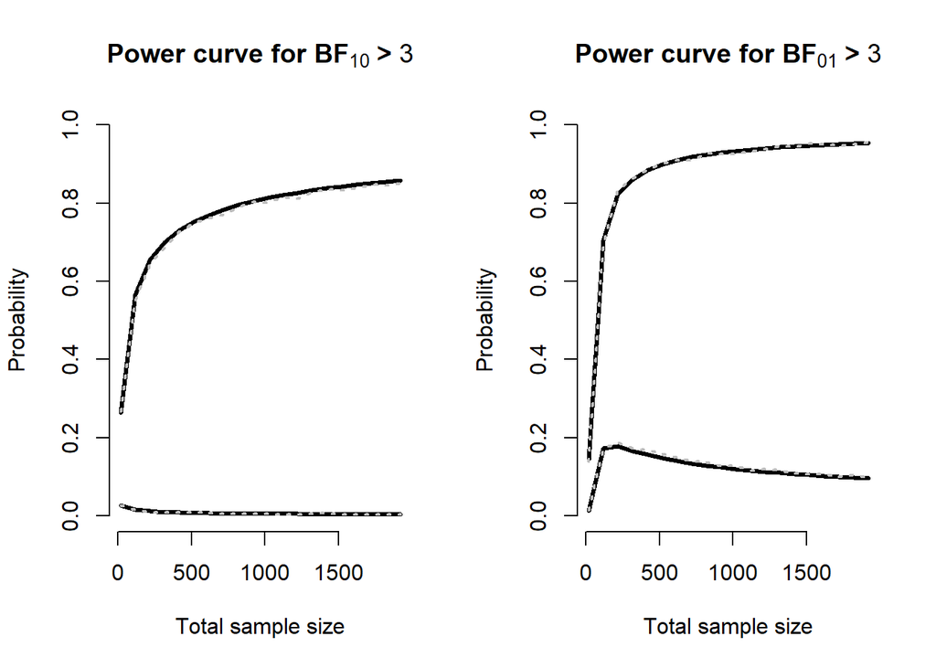

```r
  par(mfrow = c(1, 2))
  plot(total, numeric_ones[,1],
       type       = "l",
       xlab       = "Total sample size",
       ylab       = "Probability",
       ylim       = c(0,1),
       frame.plot = FALSE,
       lwd        = 3,
       main       = bquote(bold("Power curve for BF"[10]~">"~.(threshold))))
  lines(total, simulated[,1],    col = "gray",  lwd = 2, lty = 3)
  lines(total, numeric_ones[,2], col = "black", lwd = 3)
  lines(total, simulated[,2],    col = "grey",  lwd = 2, lty = 3)

  plot(total, numeric_ones[,3],
       type       = "l",
       xlab       = "Total sample size",
       ylab       = "Probability",
       ylim       = c(0,1),
       frame.plot = FALSE,
       lwd        = 3,
       main       = bquote(bold("Power curve for BF"[0][1]~">"~.(threshold))))
  lines(total, simulated[,3],    col = "gray",  lwd = 2, lty = 3)
  lines(total, numeric_ones[,4], col = "black", lwd = 3)
  lines(total, simulated[,4],    col = "grey",  lwd = 2, lty = 3)
```